# Finding the Biggest Determiner of Car Price at AUCTIONEXPORT.com

## Spring 2024 Data Science Project

### Name: Liam O'Donnell

**Member Contributions**

Member 1: Liam O'Donnell, Contribution: 100% (Contributed to all parts of the final project)

We, all team members, agree together that the above information is true, and we are confident about our contributions to this submitted project/final tutorial.

Liam O'Donnell, 05/06/2024

## Introduction

I have chosen to use the data set called "US Cars Dataset" from https://www.kaggle.com/datasets/doaaalsenani/usa-cers-dataset. This data set contains plenty of quantitative data about the cars which I feel will be better suited for a machine learning related project. It also has more features and the information was provided by AUCTION EXPORT.com.

In this tutorial, you will learn the basics of some machine learning classification algorithms and hopefully learn more about hypothesis testing.

The big question I wish to answer about my dataset is: Which feature of a car predicts whether a car is cheap?

## Data Curation

For data curation, I will be making the Pandas dataframe with the cars dataset csv file and will be performing data cleaning and preprocessing.

Imports

```python
import pandas as pd
import scipy
import matplotlib.pyplot as plt
import numpy as np # for nan
import seaborn as sns

# for machine learning
from sklearn.neighbors import KNeighborsClassifier
from sklearn.tree import DecisionTreeClassifier
from sklearn.ensemble import RandomForestClassifier
from sklearn.model_selection import train_test_split
from sklearn.metrics import accuracy_score, classification_report
```

First, we want to make a Pandas dataframe that contains the information stored in USA_cars_datasets.csv.

```python
df = pd.read_csv("USA_cars_datasets.csv")
df.head()
```

|  | Unnamed: 0 | price | brand | model | year | title_status | mileage | color | vin | lot | state | country | condition |
| --- | --- | --- | --- | --- | --- | --- | --- | --- | --- | --- | --- | --- | --- |
| 0 | 0 | 6300 | toyota | cruiser | 2008 | clean vehicle | 274117.0 | black | jtezu11f88k007763 | 159348797 | new jersey | usa | 10 days left |
| 1 | 1 | 2899 | ford | se | 2011 | clean vehicle | 190552.0 | silver | 2fmdk3gc4bbb02217 | 166951262 | tennessee | usa | 6 days left |
| 2 | 2 | 5350 | dodge | mpv | 2018 | clean vehicle | 39590.0 | silver | 3c4pdcgg5jt346413 | 167655728 | georgia | usa | 2 days left |
| 3 | 3 | 25000 | ford | door | 2014 | clean vehicle | 64146.0 | blue | 1ftfw1et4efc23745 | 167753855 | virginia | usa | 22 hours left |
| 4 | 4 | 27700 | chevrolet | 1500 | 2018 | clean vehicle | 6654.0 | red | 3gcpcrec2jg473991 | 167763266 | florida | usa | 22 hours left |

Let us see how many rows and columns are in this dataframe.

```python
num_rows = len(df)
num_columns = len(df.columns)
print("Rows: " + str(num_rows))
print("Columns: " + str(num_columns))
```

```
Rows: 2499
Columns: 13
```

**Data Cleaning and Preprocessing**

First, I would like to know if there are any null values in the data set for mileage.

```python
print(df['mileage'].isna().values.any())
```

```
False
```

Now, I would like to know if there are any null values in the data set for color.

```python
print(df['color'].isna().values.any())
```

```
False
```

I have noticed that while there are no null values in the color column, there are values called "color:" which must be nan. I would like to change 'color:' to nan and see how many values are nan.

```python
df['color'].replace("color:", np.nan, inplace=True)
num_null = df[df['color'].isna()].count()
print(num_null)
```

```
Unnamed: 0      5
price           5
brand           5
model           5
year            5
title_status    5
mileage         5
color           0
vin             5
lot             5
state           5
country         5
condition       5
dtype: int64
```

```python
num_null / num_rows
```

```
Unnamed: 0      0.002001
price           0.002001
brand           0.002001
model           0.002001
year            0.002001
title_status    0.002001
mileage         0.002001
color           0.000000
vin             0.002001
lot             0.002001
state           0.002001
country         0.002001
condition       0.002001
dtype: float64
```

Since only about 0.2 percent of the cars are nan, we can simply drop them and do not need to worry about imputation.

```python
df = df.dropna()
```

**One Hot Encoding**

The dataframe contains a lot of categorical data such as color, brand, model, state, and country. I would like to use one hot encoding to allow for a machine learning algorithm to analyze the data without thinking that, say one color is superior to another. I will be using the get_dummies function to do this.

```python
# this will be X
df2 = df.copy()
df2.drop('price', axis=1, inplace=True)
df2.drop('vin', axis=1, inplace=True)
df2.drop('lot', axis=1, inplace=True)
df2.drop('Unnamed: 0', axis=1, inplace=True)

# condition is just time until auction ends, definitely
# not condition of the vehicle so I should not care about it.
df2.drop('condition', axis=1, inplace=True)

df2 = pd.get_dummies(df2, columns=['color'])
df2 = pd.get_dummies(df2, columns=['brand'])
df2 = pd.get_dummies(df2, columns=['title_status'])
df2 = pd.get_dummies(df2, columns=['state'])
df2 = pd.get_dummies(df2, columns=['country'])
df2 = pd.get_dummies(df2, columns=['model'])

#df2 = pd.concat([df2, pd.get_dummies(df['state'], prefix='state')])
# brand seems to result in all NaN, perhaps there are too many brands?
df2.head()
```

|  | year | mileage | color_beige | color_billet silver metallic clearcoat | color_black | color_black clearcoat | color_blue | color_bright white clearcoat | color_brown | color_burgundy | ... | model_van | model_vans | model_vehicl | model_versa | model_volt | model_wagon | model_x3 | model_xd | model_xt5 | model_xterra |
| --- | --- | --- | --- | --- | --- | --- | --- | --- | --- | --- | --- | --- | --- | --- | --- | --- | --- | --- | --- | --- | --- |
| 0 | 2008 | 274117.0 | False | False | True | False | False | False | False | False | ... | False | False | False | False | False | False | False | False | False | False |
| 1 | 2011 | 190552.0 | False | False | False | False | False | False | False | False | ... | False | False | False | False | False | False | False | False | False | False |
| 2 | 2018 | 39590.0 | False | False | False | False | False | False | False | False | ... | False | False | False | False | False | False | False | False | False | False |
| 3 | 2014 | 64146.0 | False | False | False | False | True | False | False | False | ... | False | False | False | False | False | False | False | False | False | False |
| 4 | 2018 | 6654.0 | False | False | False | False | False | False | False | False | ... | False | False | False | False | False | False | False | False | False | False |

5 rows × 252 columns

## Exploratory Data Analysis

In this section, we will be learning be using hypothesis testing to learn more about the dataset.

**Statistical Method 1: ANOVA test**

I would like to know whether there is a correlation between the vehicle's color and its mileage on the auction website for colors with car mileages greater than 100000.

- H0: There is no correlation between a vehicle's color and its mileage.
- H: There is a correlation between a vehicle's color and its mileage.

```
<BarContainer object of 5 artists>
```

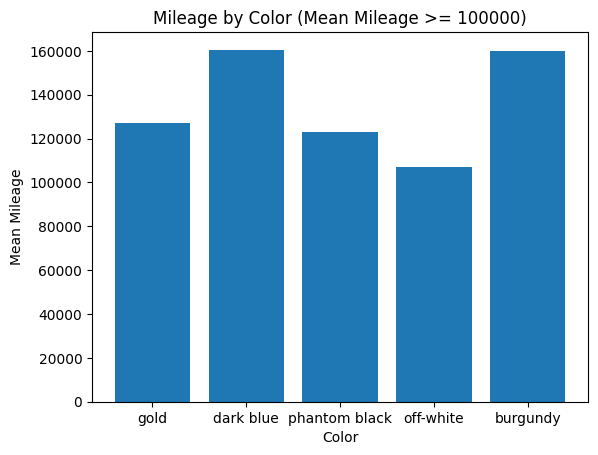

```python
color_lst = df['color'].unique().tolist()
avg_mileages = []
colors = []

for val in color_lst:
  if df['mileage'][df['color'] == val].mean() >= 100000:
    colors.append(val)

for color in colors:
  avg_mileages.append(df['mileage'][df['color'] == color].mean())

plt.title("Mileage by Color (Mean Mileage >= 100000)")
plt.xlabel("Color")
plt.ylabel("Mean Mileage")

plt.bar(colors, avg_mileages)
```

I believe an ANOVA test for colors with means greater than 100,000 would be most appropriate here as I want to compare the means of over 3 different groups of cars as there are many car colors.

```python
gold_samp = df['mileage'][df["color"] == 'gold']
blue_samp = df['mileage'][df["color"] == 'dark blue']
phantom_samp = df['mileage'][df["color"] == 'phantom black']
white_samp = df['mileage'][df["color"] == 'off-white']
burg_samp = df['mileage'][df["color"] == 'burgundy']

result = scipy.stats.f_oneway(gold_samp, blue_samp, \
phantom_samp, white_samp, burg_samp)

print("P-Value: " + str(result.pvalue))
```

```
P-Value: 0.9992505081443536
```

Since the P-value is greater than a = 0.05, I should not reject the null hypothesis and thus there is no correlation between a car's color and its mileage.

From the graph, it appears that dark blue and burgundy have the greatest average mileage.

**Statistical Method 2: Chi-Square Test**

Next, I would like to know if a car being silver is correlated with its model in the auction website.

- H0: There is no correlation between a car being silver and its model.
- H: There is a correlation between a car being silver and its model.

I want to make a column called is_silver to keep track of which cars are silver and which ones are not.

```python
def is_silver(color):
  return color == "silver"

df["is_silver"] = df['color'].apply(is_silver)
df.head()
```

|  | Unnamed: 0 | price | brand | model | year | title_status | mileage | color | vin | lot | state | country | condition | is_silver |
| --- | --- | --- | --- | --- | --- | --- | --- | --- | --- | --- | --- | --- | --- | --- |
| 0 | 0 | 6300 | toyota | cruiser | 2008 | clean vehicle | 274117.0 | black | jtezu11f88k007763 | 159348797 | new jersey | usa | 10 days left | False |
| 1 | 1 | 2899 | ford | se | 2011 | clean vehicle | 190552.0 | silver | 2fmdk3gc4bbb02217 | 166951262 | tennessee | usa | 6 days left | True |
| 2 | 2 | 5350 | dodge | mpv | 2018 | clean vehicle | 39590.0 | silver | 3c4pdcgg5jt346413 | 167655728 | georgia | usa | 2 days left | True |
| 3 | 3 | 25000 | ford | door | 2014 | clean vehicle | 64146.0 | blue | 1ftfw1et4efc23745 | 167753855 | virginia | usa | 22 hours left | False |
| 4 | 4 | 27700 | chevrolet | 1500 | 2018 | clean vehicle | 6654.0 | red | 3gcpcrec2jg473991 | 167763266 | florida | usa | 22 hours left | False |

Now I want to make a contingency table and then apply a Chi-Squared test as model is categorical data.

```python
contingency = pd.crosstab(df['model'], df['is_silver'])
display(contingency)
```

| is_silver model | False | True |
| --- | --- | --- |
| 1500 | 34 | 5 |
| 2500 | 7 | 1 |
| 2500hd | 1 | 0 |
| 300 | 6 | 0 |
| 3500 | 4 | 0 |
| ... | ... | ... |
| wagon | 28 | 2 |
| x3 | 2 | 0 |
| xd | 1 | 0 |
| xt5 | 1 | 0 |
| xterra | 1 | 0 |

126 rows × 2 columns

Now apply the Chi-Squared test.

```python
result = scipy.stats.chi2_contingency(contingency)
print("P-value: " + str(result.pvalue))
```

```
P-value: 0.00010232829755263219
```

Since the P-value is less than the alpha value (level of significance) of 0.05, I should reject the null hypothesis and therefore, a car being silver and the model of the car are correlated.

Here is a plot representing the relationship between whether a car is silver and car model.

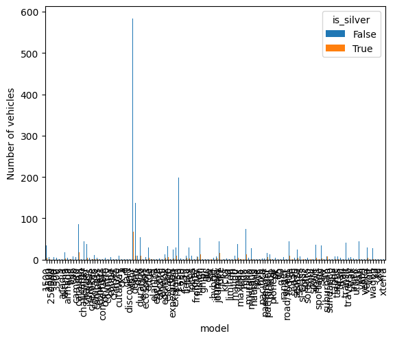

```python
contingency.plot.bar(ylabel="Number of vehicles")
```

**Statistical Method 3: Two Sample T-test**

Finally, I would like to know if a car being silver is correlated with its price on the auction website.

- H0: A car being silver is not correlated with its price.
- H: A car being silver is correlated with its price.

I feel that a two-sample T-test should be sufficient for establishing whether there is a correlation as I am comparing two groups: silver and not silver and the other variable is quantitative. I should put the prices for the silver cars in one list and the prices for the non-silver cars in another list.

```python
silver_df = df[df['color'] == 'silver']
not_silver_df = df[df['color'] != 'silver']
result = scipy.stats.ttest_ind(silver_df['price'], not_silver_df['price'])
print("P-value: " + str(result.pvalue))
```

```
P-value: 0.05136574230380793
```

Since the p value is greater than the alpha value of 0.05, I should not reject the null hypothesis and therefore, there is no correlation between a car being silver or not and its price.

Now we can make a plot.

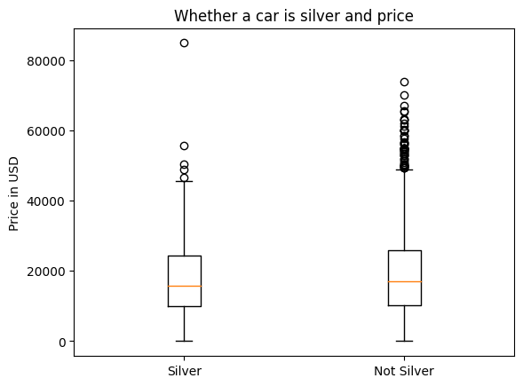

```python
silver_data = {"Silver": silver_df['price'], \
               "Not Silver": not_silver_df['price']}

# need to have two box plots for silver and not silver data
temp, graph = plt.subplots()
graph.boxplot(silver_data.values())
graph.set_xticklabels(silver_data.keys())
plt.title("Whether a car is silver and price")
plt.ylabel("Price in USD")

#plt.show()
```

There seem to be a lot of outliers in the "Not Silver" box plot.

## Primary analysis

In this section, we will be using machine learning to attempt to find the best predictors of car price on the car auction website. We would like to solve the big question brought up in the introduction which is: What features of a car on this auction website is the best predictor of whether a car is cheap?

I have heard that random forest supervised machine learning models have very high accuracy for testing data as it is an ensemble of decision trees in which the decision trees that have overfitting are outvoted by the better decision trees. Decision trees on the other hand are more likely to overfit. We will compare the two machine learning models below in terms of accuracy and F1 score.

What I need to determine is what is the maximum price a car can have and still be considered cheap at this auction? For this, I will say that a car with a price below the mean is cheap for the auction website. Now, I will find the mean.

```python
mean = np.mean(df['price'])
print(mean)
```

```
18781.55092221331
```

I need to find the features (X) and the target label of cost (y) in the dataset. Fortunately, I already found them in the one hot encoding section. I stored the features in the dataframe df2 when I was one hot encoding the categorical columns.

```python
X = df2
y = df[["price"]] < mean
```

Now, we will be splitting the data into training and testing data. In this case, the test size argument is 0.2 which indicates that 80 percent of the data will be for training and 20 percent of the data will be for testing.

```python
X_train, X_test, y_train, y_test = train_test_split(X, y, test_size=0.2, \
                                                    random_state=42)
```

**Choosing the best model**

In this tutorial, the machine learning algorithms we will be using are all supervised. What this means is that the training data that we provide the model with must be labeled.

K-NEAREST NEIGHBORS

The first classfication supervised machine learning model we will be using is a K-Nearest Neighbors classification model.

In K-nearest neighbors, for each unknown datapoint, whichever class the majority of a certain number k neighbors belong to will be what the unknown datapoint will be categorized as. Typically, the value of k is an odd natural number to prevent ties. K-nearest neighbors determines the closes neighbors typically using the Euclidean distance formula.

Let us initialize a few K-nearest neighbors models with different values of K. The reason we are doing this is because there is not one value of k that is best for all cases.

```python
knn_model = KNeighborsClassifier() # by default n_neighbors = 5
knn_model2 = KNeighborsClassifier(n_neighbors=3)
knn_model3 = KNeighborsClassifier(n_neighbors=7)
```

Now train the models

```python
knn_model.fit(X_train, np.ravel(y_train))
knn_model2.fit(X_train, np.ravel(y_train))
knn_model3.fit(X_train, np.ravel(y_train))
```

```
KNeighborsClassifier(n_neighbors=7)
```

Now we can print a classification report for each of the 3 KNN models.

```python
knn_report = classification_report(y_true = y_test,\
    y_pred = knn_model.predict(X_test))
knn2_report = classification_report(y_true = y_test,\
    y_pred = knn_model2.predict(X_test))
knn3_report = classification_report(y_true = y_test,\
    y_pred = knn_model3.predict(X_test))
print("k=5:")
print(knn_report)
print("k=3:")
print(knn2_report)
print("k=7:")
print(knn3_report)
```

```
k=5:
              precision    recall  f1-score   support

       False       0.61      0.61      0.61       199
        True       0.74      0.74      0.74       300

    accuracy                           0.69       499
   macro avg       0.68      0.68      0.68       499
weighted avg       0.69      0.69      0.69       499

k=3:
              precision    recall  f1-score   support

       False       0.58      0.61      0.59       199
        True       0.73      0.71      0.72       300

    accuracy                           0.67       499
   macro avg       0.65      0.66      0.66       499
weighted avg       0.67      0.67      0.67       499

k=7:
              precision    recall  f1-score   support

       False       0.59      0.60      0.59       199
        True       0.73      0.72      0.73       300

    accuracy                           0.67       499
   macro avg       0.66      0.66      0.66       499
weighted avg       0.67      0.67      0.67       499
```

The K=5 model seems to have the best f1-score, precision, and recall. K=3 and K=7 had very similar performance in terms of f1-score. The closer the f1 score is to 1, the better the model is as f1-score combines precision and recall.

DECISION TREE

The second model we will be initializing is a decision tree. You can find more information about decision trees here: https://scikit-learn.org/stable/modules/tree.html

Let us make a decision tree machine learning model.

```python
dtree_model = DecisionTreeClassifier()
```

Now we need to train the decision tree model.

```python
dtree_model.fit(X_train, np.ravel(y_train))
```

```
DecisionTreeClassifier()
```

Now we will be checking the decision tree model's accuracy.

```python
dtree_score = dtree_model.score(X_train, y_train)
dtree_score_test = dtree_model.score(X_test, y_test)
print("Training accuracy: " + str(dtree_score))
print("Testing accuracy: " + str(dtree_score_test))
```

```
Training accuracy: 1.0
Testing accuracy: 0.8376753507014028
```

Now we can make a classification report for the decision tree model that contains the f1 score.

```python
report = classification_report(y_true = y_test,\
    y_pred = dtree_model.predict(X_test))
print(report)
```

```
              precision    recall  f1-score   support

       False       0.79      0.81      0.80       199
        True       0.87      0.86      0.86       300

    accuracy                           0.84       499
   macro avg       0.83      0.83      0.83       499
weighted avg       0.84      0.84      0.84       499
```

RANDOM FOREST

Now, we want to make a random forest model. A random forest model is an ensemble model which is capable of assessing the performance of multiple decision trees in such a way that the decision trees that suffer from more overfitting are outvoted by other decision trees. It is considered one of the most accurate classification machine learning algorithms. If you want to learn more about random forest classification you can go to: https://www.ibm.com/topics/random-forest#:~:text=Random%20forest%20is%20a%20commonly,Decision%20trees

```python
model = RandomForestClassifier()
```

Now for training the model:

```python
model.fit(X_train, np.ravel(y_train))
```

```
RandomForestClassifier()
```

Now, I will be checking the model's training accuracy on the test data.

```python
score = model.score(X_train, y_train)
test_score = model.score(X_test, y_test)
print("Training accuracy: " + str(score))
print("Testing accuracy: " + str(test_score))
```

```
Training accuracy: 1.0
Testing accuracy: 0.8717434869739479
```

Now check the model's f1 score.

```python
report = classification_report(y_true = y_test,\
    y_pred = model.predict(X_test))
print(report)
```

```
              precision    recall  f1-score   support

       False       0.84      0.84      0.84       199
        True       0.90      0.89      0.89       300

    accuracy                           0.87       499
   macro avg       0.87      0.87      0.87       499
weighted avg       0.87      0.87      0.87       499
```

The random forest model has a rather high f1-score of 0.89. This is definitely an improvement over the decision tree model and all of the K-Nearest Neighbors models. The fact that the decision tree model performed as well as the random forest model on the training data while performing worse on the testing data indicates that the decision tree model had more overfitting. Therefore, I will use the random forest model to find the important features of the dataset.

**Determining the most important features**

Now I want to know the most important features of the dataset.

```python
feature_importances = pd.DataFrame(model.feature_importances_)
feature_importances['Feature Names'] = X.columns
feature_importances = feature_importances.sort_values(by=0, ascending = False)
feature_importances.head()
```

|  | 0 | Feature Names |
| --- | --- | --- |
| 1 | 0.194101 | mileage |
| 0 | 0.076511 | year |
| 175 | 0.040507 | model_f-150 |
| 58 | 0.030519 | brand_ford |
| 158 | 0.027763 | model_door |

It is clear that the mileage is the most important feature.

## Visualization

Since mileage was found using the Random Forest model to be the most significant feature in predicting a car's price on the auction website, we will plot a scatter plot showing the relationship between mileage and car price.

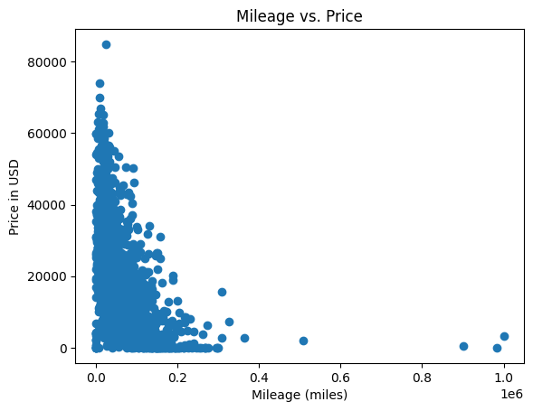

```python
plt.title("Mileage vs. Price")
plt.xlabel("Mileage (miles)")
plt.ylabel("Price in USD")

plt.scatter(df['mileage'], df['price'])
```

It is clear that the price of a car is negatively correlated with the car's mileage.

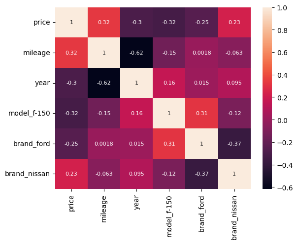

```python
X['price'] = y # price is a boolean that is true if price is less than
               # mean and false otherwise
top_data = X[['price', 'mileage', 'year', 'model_f-150',\
              'brand_ford', 'brand_nissan']]
matrix = sns.heatmap(top_data.corr(), annot=True,\
                     annot_kws={"size": 8})
```

## Insights and Conclusions

From studying this tutorial, you have learned how to perform various tests to establish the relationships between multiple variables, obtained some familiarity with machine learning classification algorithms, and an idea of how the various concepts covered apply to the real world.

Based on what we have discovered, the feature that played the greatest role in determining the price of a car being cheap or less than the mean was mileage. The second most important feature was the year.

Contribution Section 2: Liam O'Donnell contributed to the creation of the final project by working alone on all parts of the parts of the project in checkpoint 1, checkpoint 2, and checkpoint 3.